# Project Python Foundations: FoodHub Data Analysis

#### More observations behind Ratings and User Orders

I want to see if there are people ordering from a restaurant because they see that the restaurant is rated high.

```
Average Ratings Breakdown (0.1 scale) and Total Orders:
    mean_rating_rounded  order_count
0                   3.0            9
1                   3.2            4
2                   3.3            3
3                   3.5           12
4                   3.7            3
5                   3.8            4
6                   4.0           58
7                   4.1           80
8                   4.2          227
9                   4.3          331
10                  4.4          106
11                  4.5          112
12                  4.6           67
13                  4.7           48
14                  4.8            8
15                  4.9           15
16                  5.0           75
```

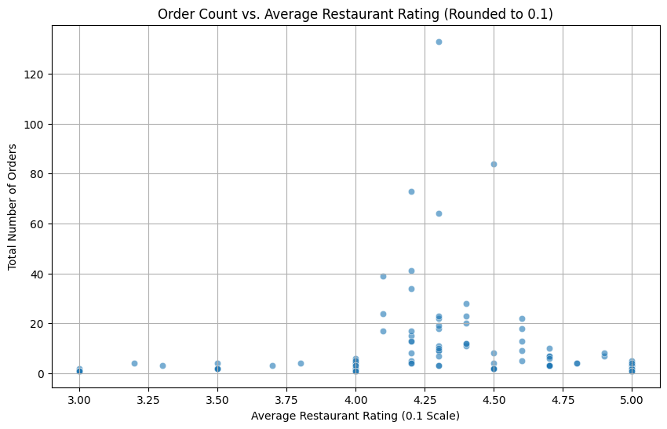

```python
# prompt: See if people are ordering more on restaurants with higher ratings. use restaurant_name for uniqueness. Show average ratings breakdown in 0.1 scale. like 4.0... 4.1... 4.2... etc.

# Remove 'Not given' ratings for this analysis
df_rated = df[df['rating'] != 'Not given'].copy()

# Convert rating to numeric
df_rated['rating'] = pd.to_numeric(df_rated['rating'])

# Group by restaurant name and calculate the mean rating and order count
restaurant_ratings = df_rated.groupby('restaurant_name').agg(
    mean_rating=('rating', 'mean'),
    order_count=('order_id', 'count')
).reset_index()

# Round the mean rating to 0.1 scale
restaurant_ratings['mean_rating_rounded'] = (restaurant_ratings['mean_rating'] * 10).round() / 10

# Group by the rounded rating and sum the order counts
orders_by_rounded_rating = restaurant_ratings.groupby('mean_rating_rounded')['order_count'].sum().reset_index()

print("Average Ratings Breakdown (0.1 scale) and Total Orders:")
print(orders_by_rounded_rating)

# Visualize the relationship
plt.figure(figsize=(10, 6))
sns.scatterplot(data=restaurant_ratings, x='mean_rating_rounded', y='order_count', alpha=0.6)
plt.title('Order Count vs. Average Restaurant Rating (Rounded to 0.1)')
plt.xlabel('Average Restaurant Rating (0.1 Scale)')
plt.ylabel('Total Number of Orders')
plt.grid(True)
plt.show()
```

```
Average Orders per Restaurant within each Rounded Rating Bin:
    mean_rating_rounded  average_orders_per_restaurant_in_bin
0                   3.0                              1.125000
1                   3.2                              4.000000
2                   3.3                              3.000000
3                   3.5                              2.400000
4                   3.7                              3.000000
5                   3.8                              4.000000
6                   4.0                              2.000000
7                   4.1                             26.666667
8                   4.2                             20.636364
9                   4.3                             25.461538
10                  4.4                             17.666667
11                  4.5                             10.181818
12                  4.6                             13.400000
13                  4.7                              4.800000
14                  4.8                              4.000000
15                  4.9                              7.500000
16                  5.0                              1.595745
```

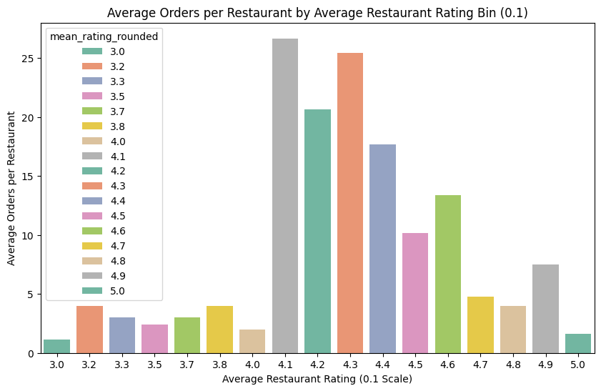

```python
# To specifically show the average orders for each rounded rating bin
avg_orders_per_rating_bin = orders_by_rounded_rating.copy()
# We can't directly get avg orders *per restaurant* in the bin this way, as it requires another group by
# Let's recalculate the average orders per rating bin based on number of restaurants in each bin
restaurant_count_per_rating_bin = restaurant_ratings.groupby('mean_rating_rounded').size().reset_index(name='restaurant_count')
avg_orders_per_rating_bin = pd.merge(orders_by_rounded_rating, restaurant_count_per_rating_bin, on='mean_rating_rounded')
avg_orders_per_rating_bin['average_orders_per_restaurant_in_bin'] = avg_orders_per_rating_bin['order_count'] / avg_orders_per_rating_bin['restaurant_count']

print("\nAverage Orders per Restaurant within each Rounded Rating Bin:")
print(avg_orders_per_rating_bin[['mean_rating_rounded', 'average_orders_per_restaurant_in_bin']])

plt.figure(figsize=(10, 6))
sns.barplot(
    data=avg_orders_per_rating_bin,
    x='mean_rating_rounded',
    y='average_orders_per_restaurant_in_bin',
    hue='mean_rating_rounded',
    palette='Set2'
)
plt.title('Average Orders per Restaurant by Average Restaurant Rating Bin (0.1)')
plt.xlabel('Average Restaurant Rating (0.1 Scale)')
plt.ylabel('Average Orders per Restaurant')
plt.show()
```

Higher ratings don't seem to necessarily dictate the order volume. It's a combination of volume and rating (has to be higher than 4.0 but the volume drops off after 4.5)

We can recommend users to restaurants based both on other user engagements as well as the restaurant's ratings to closely tie the relationships together.

### **Question 13:** The company wants to provide a promotional offer in the advertisement of the restaurants. The condition to get the offer is that the restaurants must have a rating count of more than 50 and the average rating should be greater than 4. Find the restaurants fulfilling the criteria to get the promotional offer. [3 marks]

```python
rated_df = df[df['rating'] != 'Not given'].copy()
rated_df['rating'] = rated_df['rating'].astype(float)

restaurant_ratings = rated_df.groupby('restaurant_name')['rating'].agg(['count', 'mean'])

promo_restaurants = restaurant_ratings[(restaurant_ratings['count'] > 50) & (restaurant_ratings['mean'] > 4)]

print("Restaurants fulfilling the promotional offer criteria:")
print(promo_restaurants)
```

```
Restaurants fulfilling the promotional offer criteria:
                           count      mean
restaurant_name
Blue Ribbon Fried Chicken     64  4.328125
Blue Ribbon Sushi             73  4.219178
Shake Shack                  133  4.278195
The Meatball Shop             84  4.511905
```

#### Observations:

```
                           count      mean
restaurant_name
Blue Ribbon Fried Chicken     64  4.328125
Blue Ribbon Sushi             73  4.219178
Shake Shack                  133  4.278195
The Meatball Shop             84  4.511905
```

### **Question 14:** The company charges the restaurant 25% on the orders having cost greater than 20 dollars and 15% on the orders having cost greater than 5 dollars. Find the net revenue generated by the company across all orders. [3 marks]

```python
def compute_revenue(cost):
    if cost > 20:
        return cost * 0.25
    elif cost > 5:
        return cost * 0.15
    else:
        return 0

df['revenue'] = df['cost_of_the_order'].apply(compute_revenue)
total_revenue = df['revenue'].sum()
print(f"Net revenue generated by the company: ${total_revenue:.2f}")
```

```
Net revenue generated by the company: $6166.30
```

#### Observations:

```
Net revenue generated by the company: $6166.30
```

### **Question 15:** The company wants to analyze the total time required to deliver the food. What percentage of orders take more than 60 minutes to get delivered from the time the order is placed? (The food has to be prepared and then delivered.) [2 marks]

```python
def calculate_total_time(row):
    return row['food_preparation_time'] + row['delivery_time']

df['total_time'] = df.apply(calculate_total_time, axis=1)

orders_over_60_minutes = df[df['total_time'] > 60]

percentage_over_60 = (len(orders_over_60_minutes) / len(df)) * 100

print(f"Percentage of orders taking more than 60 minutes to deliver: {percentage_over_60:.2f}%")
```

```
Percentage of orders taking more than 60 minutes to deliver: 10.54%
```

#### Observations:

```
Percentage of orders taking more than 60 minutes to deliver: 10.54%
```

### **Question 16:** The company wants to analyze the delivery time of the orders on weekdays and weekends. How does the mean delivery time vary during weekdays and weekends? [2 marks]

```
Mean delivery time (minutes) by day of the week:
day_of_the_week
Weekday    28.340037
Weekend    22.470022
Name: delivery_time, dtype: float64
```

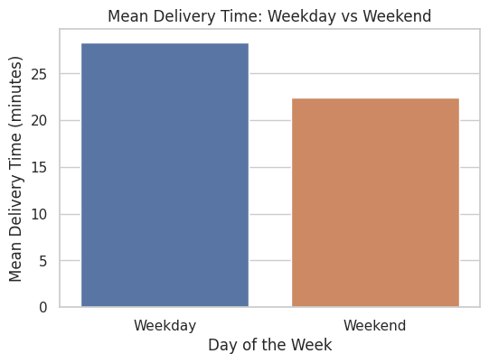

```python
delivery_time_by_day = df.groupby('day_of_the_week')['delivery_time'].mean()

print("Mean delivery time (minutes) by day of the week:")
print(delivery_time_by_day)

plt.figure(figsize=(6, 4))
sns.barplot(
    x=delivery_time_by_day.index,
    y=delivery_time_by_day.values,
    hue=delivery_time_by_day.index,
    palette='deep')
plt.title("Mean Delivery Time: Weekday vs Weekend")
plt.xlabel("Day of the Week")
plt.ylabel("Mean Delivery Time (minutes)")
plt.show()
```

#### Observations:

```
Mean delivery time (minutes) by day of the week:
day_of_the_week   mean
Weekday           28.340037
Weekend           22.470022
```

The delivery time takes longer on the weekdays than it takes on weekends.

### Conclusion and Recommendations

### **Question 17:** What are your conclusions from the analysis? What recommendations would you like to share to help improve the business? (You can use cuisine type and feedback ratings to drive your business recommendations.) [6 marks]

```python
total_orders = len(df)
unrated_orders = (df['rating'] == 'Not given').sum()
pct_unrated = 100 * unrated_orders / total_orders

print(f"Unrated orders: {unrated_orders} of {total_orders} → {pct_unrated:.1f}% didn’t leave a star.")
```

```
Unrated orders: 736 of 1898 → 38.8% didn’t leave a star.
```

### Conclusions:

- **Cuisine Popularity:** American and Japanese cuisines are the most popular, especially on weekends. This suggests a strong demand for comfort food during leisure days.
- **Delivery Time Variation:** Delivery times are significantly longer on weekdays compared to weekends. This could be due to factors like traffic, order volume distribution, or driver availability.
- **Restaurant Performance:** A few restaurants (Shake Shack, The Meatball Shop, Blue Ribbon Sushi, Blue Ribbon Fried Chicken) consistently receive high ratings and have a significant number of orders.
- **Order Cost and Revenue:** A substantial portion of orders (around 29%) are over $20, contributing a higher percentage of revenue per order to the company. The orders below $20 may be potential target for revenue growth.
- **Rating Participation:** A large number of orders are not rated, which limits the ability to fully understand customer satisfaction across all transactions. 736 of 1898 → 38.8% are marked 'Not given'.

### Recommendations:

By focusing on top restaurants and cuisines and high weekend engagments, FoodHub can enhance customer experience, strengthen restaurant partnerships, and ultimately drive business growth.

```python
!jupyter nbconvert \
    --to html \
    "/content/drive/My Drive/Colab Notebooks/Learner_Notebook_Full_Code.ipynb" \
    --output "/content/drive/My Drive/Colab Notebooks/Learner_Notebook_Full_Code.html"
```

```
[NbConvertApp] Converting notebook /content/drive/My Drive/Colab Notebooks/Learner_Notebook_Full_Code.ipynb to html
[NbConvertApp] WARNING | Alternative text is missing on 35 image(s).
[NbConvertApp] Writing 2613097 bytes to /content/drive/My Drive/Colab Notebooks/Learner_Notebook_Full_Code.html
```